# IODS-course final assignment

Elina Turunen

#### Abstract

This exercise concerns objective and subjective measures of well-being. Research questions are what is explaining happiness, freedom and higher freedom in the data, and which variables are most important in dividing data. The data originates from the World Happiness Report that examines happiness and subjective well-being as measures of human development. Methods used are multiple regression, logistic regression and principal component analysis.

GDP per capita, social support, healthy life expectancy, freedom and absence of corruption are positively correlated with happiness explaining 78 % of the variation of the happiness score. Trust-related variables social support, absence of corruption and generosity are positively correlated with freedom and high freedom. Most of the variance from the features and greater share of differences between countries is explained by GDP per capita, healthy life expectancy, social support and happiness score. First two of these variables could be dividing different levels of development. Other variables like trust and abilities are possibly needed to give meaning to the concept. If freedom is of interest, more specific questions could enhance the study.

#### Research questions

Happiness is nowadays proposed as a measure of well-being. It has been been questioned a lot for different reasons related to for example method and normativity. World Happiness Report (2016) examines happiness as a measure of well-being. In this exercise variables of the report, which perhaps not all are traditionally used, will be looked at, and the data of the report will be used.

First the basic setting will be explored  
*What is explaining happiness in the data?*

The happiness score can be regarded quite vague. Autonomy of people seems more interesting in a sense that it has to do with rights, not affects or emotions. They are not unnecessary, but hard to propose as a legitimate policy targets. Therefore I will look at  
*What is explaining freedom in the data?*  
*And higher freedom?*

Some aspects of data might be more important than others, than e.g. happiness or freedom, so it is also good to explore.  
*Which variables are most important in dividing data?*

#### Data

The data originates from the World Happiness Report and it is downloaded from kaggle.com. The first such report was published in 2012 in support of the High Level Meeting at the United Nations on happiness and well-being. 2016 update is edited by John Helliwell, Richard Layard and Jeffrey Sachs. The report is published by The Sustainable Development Solutions Network (SDSN) that was commissioned by UN Secretary-General Ban Ki-moon.

The report is a survey of the state of global happiness. It examines happiness and subjective well-being as measures human development. It was also done for policy use. Survey questions originate from the Gallup World Poll that was carried out by Gallup Inc. It provided data for the study. Some measures are created with data from the World Bank, OECD and WHO.

The variables of the data are as follows:

- Happiness score is based on answers to the life evaluation question of rating current lives on a scale from 0 (worst) to 10 (best), that is the so-called Cantril ladder. Happiness rank is the happiness score put in order. The happiness score is intended to represent people’s happiness.
- GDP per capita is gross domestic product per capita in purchasing power parity, PPP, at dollar prices. The equation uses the natural log of GDP per capita.
- Healthy life expectancy is healthy life expectancy at birth. This and previous variable represent state of economy and general level of health sector of countries.
- Freedom is satisfaction with freedom to choose what to do with ones life (national average of binary responses). It portrays chances and limitations to act.
- Family variable is supposed to describe social support: having relatives or friends one can count on when help is needed (national average of binary responses).
- Trust is national average of responses to questions is corruption widespread throughout the government and within businesses (average of binary responses). Low values refer to corruption and high values to absence of corruption.
- Generosity is the residual of regressing national average of responses to question of donating money to a charity in the past month (binary) on GDP per capita. It is supposed to describe people’s will to help others.
- Dystopia residual variable is a hypothetical country that has values equal to world’s lowest national averages for each of the six factors other than happiness. It was used as a benchmark against which countries can be compared in terms of six key variables and letting sub-bars of these variables to be of positive width in the report.

Focus on inequality was new in the report 2016 update. Unfortunately some variables were not available in kaggle, for example the gini of household income and gini index. They would have been important variables for the exercise.

#### Data wrangling

Before analysis I changed column names to shorter descriptive names. I excluded variables happiness rank, region, dystopia and confidence intervals. I changed country column to name the rows and excluded the country column.

Script here: https://github.com/elinaturunen/IODS-final/blob/master/final.R

#### Explorations of the variables

First I had to fix rownames, because they did not preserve (there was a problem).

```r
happiness2 <- read.table("happiness2.csv", sep = ",", header=TRUE)
str(happiness2)
```

```
## 'data.frame':    157 obs. of  8 variables:
##  $ X            : Factor w/ 157 levels "Afghanistan",..: 38 135 58 104 45 26 98 99 7 134 ...
##  $ happ.score   : num  7.53 7.51 7.5 7.5 7.41 ...
##  $ gdpcapita    : num  1.44 1.53 1.43 1.58 1.41 ...
##  $ socialsupport: num  1.16 1.15 1.18 1.13 1.13 ...
##  $ hlifeexp     : num  0.795 0.863 0.867 0.796 0.811 ...
##  $ freedom      : num  0.579 0.586 0.566 0.596 0.571 ...
##  $ corruption   : num  0.445 0.412 0.15 0.358 0.41 ...
##  $ generosity   : num  0.362 0.281 0.477 0.379 0.255 ...
```

```r
colnames(happiness2)[1] <- "country"
rownames(happiness2) <- happiness2$country
happiness2 <- dplyr::select(happiness2, -country)
```

Then I looked at the distributions of the variables by drawing a histogram and printing a summary of the variables. Then I draw ggpairs to look at the relations of the variables.

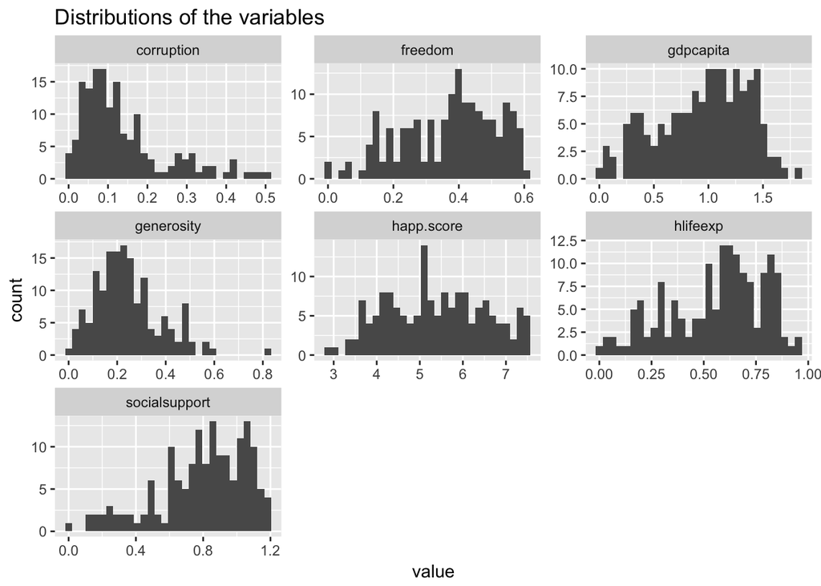

```r
library(ggplot2); library(GGally); library(tidyr); library(dplyr)

gather(happiness2) %>% ggplot(aes(value)) + geom_histogram() + facet_wrap("key", scales = "free") + ggtitle("Distributions of the variables")
```

```r
summary(happiness2)
```

```
##    happ.score      gdpcapita      socialsupport       hlifeexp
##  Min.   :2.905   Min.   :0.0000   Min.   :0.0000   Min.   :0.0000
##  1st Qu.:4.404   1st Qu.:0.6702   1st Qu.:0.6418   1st Qu.:0.3829
##  Median :5.314   Median :1.0278   Median :0.8414   Median :0.5966
##  Mean   :5.382   Mean   :0.9539   Mean   :0.7936   Mean   :0.5576
##  3rd Qu.:6.269   3rd Qu.:1.2796   3rd Qu.:1.0215   3rd Qu.:0.7299
##  Max.   :7.526   Max.   :1.8243   Max.   :1.1833   Max.   :0.9528
##     freedom         corruption        generosity
##  Min.   :0.0000   Min.   :0.00000   Min.   :0.0000
##  1st Qu.:0.2575   1st Qu.:0.06126   1st Qu.:0.1546
##  Median :0.3975   Median :0.10547   Median :0.2225
##  Mean   :0.3710   Mean   :0.13762   Mean   :0.2426
##  3rd Qu.:0.4845   3rd Qu.:0.17554   3rd Qu.:0.3119
##  Max.   :0.6085   Max.   :0.50521   Max.   :0.8197
```

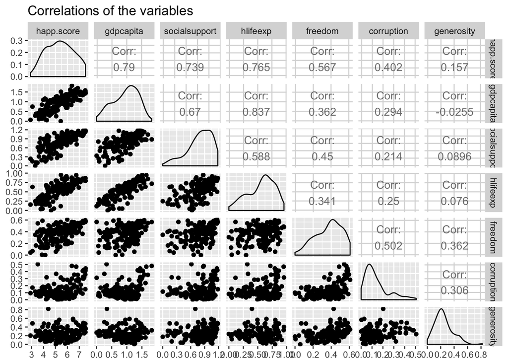

```r
p <- ggpairs(happiness2, mapping = aes(), lower = list(combo = wrap("facethist", bins = 20))) + ggtitle("Correlations of the variables")
p
```

Most of the variables are binary of which national average has been taken. They are not distributed very evenly. The variables describe differences between countries in certain things. There are a few countries where there is perception of absence of corruption, the perception being more often that corruption is widespread in the government and within businesses. Social support is leaning towards higher social support. It is a variable not necessarily dependent on country’s economy. GDP per capita, healthy life expectancy and freedom are also leaning to right that is higher GDP, life expectancy and freedom, GDP being a bit more varied. The generosity variable leans to lower generosity. Only a few countries have higher generosity. The happiness score is relatively evenly distributed if one can say so. So there are differences in rating life happiness. It is interesting that distributions of corruption and freedom reach only maximum values 0.6 for freedom and 0.5 for corruption.

GDP per capita, social support and healthy life expectancy have strong correlation with the happiness score, and quite strong for it and freedom. So it seems that there is correlation between the happiness score and other variables, which is no surprise since the data is very much tested and used beforehand. Also freedom variable seems to be positively correlated with other variables. Strong correlation can be found between GDP per capita and healthy life expectancy and quite strong for social support; quite strong for social support and healthy life expectancy; and freedom and corruption.

#### Methods

First multiple regression is performed to see if variables are correlated with the happiness score, it being the dependent variable. Then the same is done for freedom variable it being dependent (without happiness score) and for higher freedom. Then variance in the data is explored by using the principal component analysis.

#### Results

First I did multiple regression with happiness score as a dependent variable.

```r
m <- lm(happ.score ~ gdpcapita + socialsupport + hlifeexp + freedom + corruption + generosity, data = happiness2)
summary(m)
```

```
##
## Call:
## lm(formula = happ.score ~ gdpcapita + socialsupport + hlifeexp +
##     freedom + corruption + generosity, data = happiness2)
##
## Residuals:
##      Min       1Q   Median       3Q      Max
## -1.45150 -0.27143 -0.03336  0.32519  1.48213
##
## Coefficients:
##               Estimate Std. Error t value Pr(>|t|)
## (Intercept)     2.1903     0.1583  13.834  < 2e-16 ***
## gdpcapita       0.7214     0.2171   3.323 0.001120 **
## socialsupport   1.2298     0.2297   5.353 3.19e-07 ***
## hlifeexp        1.4364     0.3489   4.117 6.32e-05 ***
## freedom         1.5139     0.3880   3.902 0.000144 ***
## corruption      0.9189     0.4648   1.977 0.049852 *
## generosity      0.1595     0.3621   0.440 0.660236
## ---
## Signif. codes:  0 '***' 0.001 '**' 0.01 '*' 0.05 '.' 0.1 ' ' 1
##
## Residual standard error: 0.5367 on 150 degrees of freedom
## Multiple R-squared:  0.7875, Adjusted R-squared:  0.779
## F-statistic: 92.65 on 6 and 150 DF,  p-value: < 2.2e-16
```

```r
CI <- confint(m) %>% exp
cbind(CI)
```

```
##                   2.5 %    97.5 %
## (Intercept)   6.5368859 12.220640
## gdpcapita     1.3396413  3.159531
## socialsupport 2.1723094  5.385541
## hlifeexp      2.1106284  8.379765
## freedom       2.1113995  9.781754
## corruption    1.0006025  6.279257
## generosity    0.5735025  2.398830
```

In the first regression all other variables than generosity are statistically significant. The correlation is positive in all cases. For example when GDP per capita grows by one, happiness score grows by 0.7214. These variables explain 78 % of the variation of the happiness score that can be regarded a lot. I wonder why generosity is not significant in this model - is its relative effect compared to other variables low?

Some of the confidence intervals are wide, especially for healthy life expectancy and freedom. With freedom happiness will get a value between 2.1-9.8 with the probability of 95 %.

Freedom has highest estimate in the regression, but confidence interval for it is wide. Can this refer to differences in perception of the concept of freedom? For example if one understands freedom as structural things providing certain rights or personal situation, the following happiness score could vary a lot. Freedom and healthy life expectancy are perhaps not the most powerful explainers for happiness.

Healthy life expectancy, GDP per capita and absence of corruption refer to the organization of the state. Social support is not necessarily dependent on state. As said, freedom is perhaps a bit loose concept, it is possible to understand the question in many ways - freedom to choose what to do in relation to law and human rights or in relation to education system and social policy or in relation to personal situations. For example one could have high level of freedom in society in general even if one had personal hindrances such as need for rehabilitation that was not properly received. Also perceptions of absence of corruption can have a bit of bias if people have a rosy picture of their surroundings. For example Finland has been portrayed as a country of low corruption (though perhaps less recently), but it is known that corruption is not rare for example in construction business.

Research around happiness is related to sustainability goals concerning environmental sustainability. In that sense I understand that it is relevant to examine subjective well-being and not just objective and material aspects. There are however many difficulties that lie in subjective questionings. Some connect happiness studies to positive psychology and compulsion of consumer culture to be happy. Therefore it can be asked that in what sense it is contributing to sustainability.

Despite its lackings, freedom seems to me a bit more concrete or material goal than happiness. You can be happy, but not free or unhappy, but free. Freedom at least relates to some rights and possibilities, maybe there is some solid base. I’m interested in which variables have connection to freedom, are they forming chances and limitations behind it. Next I did multiple regression with freedom as dependent variable.

```r
m <- lm(freedom ~ gdpcapita + socialsupport + hlifeexp + corruption + generosity, data = happiness2)
summary(m)
```

```
##
## Call:
## lm(formula = freedom ~ gdpcapita + socialsupport + hlifeexp +
##     corruption + generosity, data = happiness2)
##
## Residuals:
##      Min       1Q   Median       3Q      Max
## -0.33619 -0.06160  0.00851  0.07244  0.25537
##
## Coefficients:
##               Estimate Std. Error t value Pr(>|t|)
## (Intercept)    0.09109    0.03237   2.814 0.005546 **
## gdpcapita      0.01186    0.04553   0.261 0.794778
## socialsupport  0.17527    0.04603   3.808 0.000204 ***
## hlifeexp       0.01244    0.07318   0.170 0.865246
## corruption     0.45828    0.09007   5.088 1.06e-06 ***
## generosity     0.24513    0.07329   3.345 0.001039 **
## ---
## Signif. codes:  0 '***' 0.001 '**' 0.01 '*' 0.05 '.' 0.1 ' ' 1
##
## Residual standard error: 0.1126 on 151 degrees of freedom
## Multiple R-squared:  0.4206, Adjusted R-squared:  0.4014
## F-statistic: 21.92 on 5 and 151 DF,  p-value: < 2.2e-16
```

```r
CI <- confint(m) %>% exp
cbind(CI)
```

```
##                   2.5 %   97.5 %
## (Intercept)   1.0275039 1.167719
## gdpcapita     0.9248731 1.107193
## socialsupport 1.0879780 1.305026
## hlifeexp      0.8762103 1.170029
## corruption    1.3235438 1.889364
## generosity    1.1055375 1.476887
```

In the second regression only social support, absence of corruption and generosity are statistically significant. There is positive correlation between these variables and freedom. For social support and generosity the correlation is not so strong. When absence of corruption grows by one, freedom grows by 0.46. The confidence intervals for the significant variables vary between around 0.2-0.5, they are not supernarrow considered in relation to the distributions of the variables.

It is comprehensible that absence of corruption is a building block of freedom to do what one wants with same rules for everyone. Why are GDP per capita and healthy life expectancy not significant here? The estimates are also very low. I would have guessed these material indicators had more effect. But the GDP per capita does not tell about the distribution of wealth in societies. Here gini would be better variable to see whether material conditions have to do with freedom. Here it seems that freedom had to do more with trust-related variables social support, corruption and generosity.

Next I did validation of the regression model with diagnostic plots, but was not able to interpret these. (Unfortunately I understood what is meant by validation task last minute and ran out of time with all these validation parts. I need to learn more on these.)

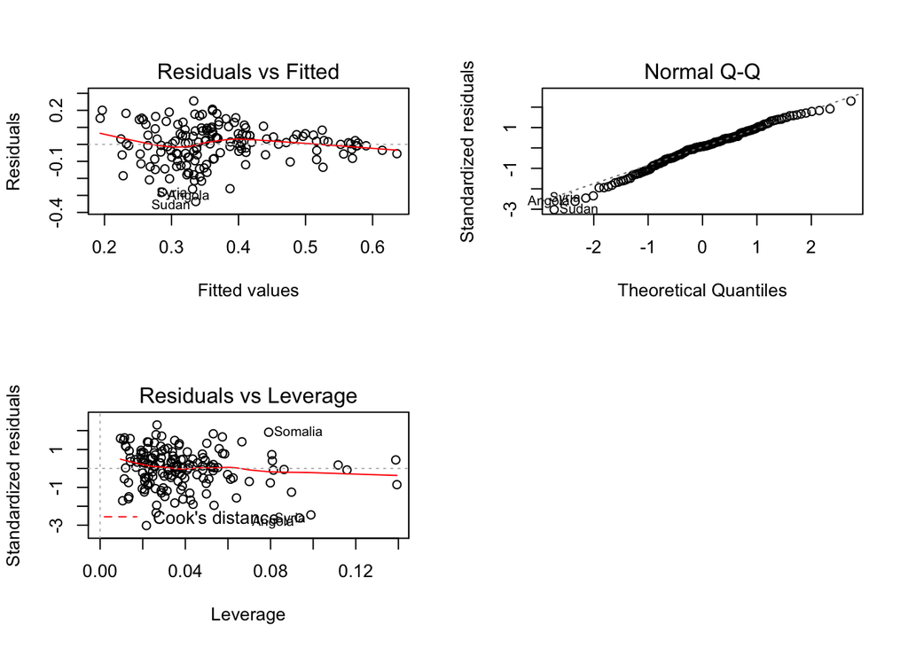

```r
model <- lm(freedom ~ gdpcapita + socialsupport + hlifeexp + corruption + generosity, data = happiness2)
par(mfrow = c(2,2))
plot(model, which = c(1,2,5))
```

Next I divided the freedom variable into two at 0.35, based on where it started getting higher values in the distribution.

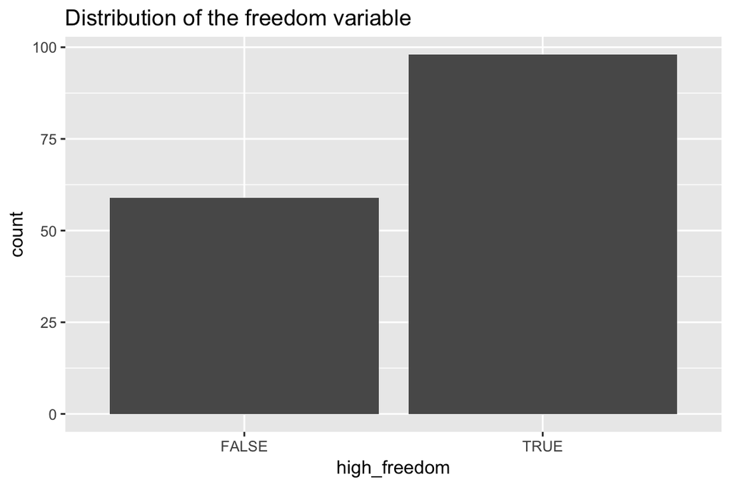

```r
happiness2_f <- mutate(happiness2, high_freedom = freedom > 0.35)
g2 <- ggplot(data = happiness2_f, aes(x = high_freedom))
g2 + geom_bar() + ggtitle("Distribution of the freedom variable")
```

It seems that greater share of values for freedom are high with the chosen limit. Next I did regression again, this time logistic regression, to see which variables have correlation with higher values of freedom.

```r
m <- glm(high_freedom ~ gdpcapita + socialsupport + hlifeexp + corruption + generosity, data = happiness2_f, family = "binomial")
summary(m)
```

```
##
## Call:
## glm(formula = high_freedom ~ gdpcapita + socialsupport + hlifeexp +
##     corruption + generosity, family = "binomial", data = happiness2_f)
##
## Deviance Residuals:
##     Min       1Q   Median       3Q      Max
## -1.9911  -0.9181   0.1447   0.8090   2.3180
##
## Coefficients:
##               Estimate Std. Error z value Pr(>|z|)
## (Intercept)    -5.3127     1.0959  -4.848 1.25e-06 ***
## gdpcapita       0.7622     1.0385   0.734 0.463019
## socialsupport   3.4732     1.0580   3.283 0.001027 **
## hlifeexp       -0.5341     1.5146  -0.353 0.724390
## corruption     11.6242     3.4358   3.383 0.000716 ***
## generosity      6.7859     2.1292   3.187 0.001437 **
## ---
## Signif. codes:  0 '***' 0.001 '**' 0.01 '*' 0.05 '.' 0.1 ' ' 1
##
## (Dispersion parameter for binomial family taken to be 1)
##
##     Null deviance: 207.86  on 156  degrees of freedom
## Residual deviance: 147.42  on 151  degrees of freedom
## AIC: 159.42
##
## Number of Fisher Scoring iterations: 6
```

```r
OR <- coef(m) %>% exp
CI <- confint(m) %>% exp
cbind(OR, CI)
```

```
##                         OR        2.5 %       97.5 %
## (Intercept)   4.928498e-03 4.683861e-04 3.527310e-02
## gdpcapita     2.142913e+00 2.813534e-01 1.702269e+01
## socialsupport 3.223932e+01 4.350616e+00 2.839469e+02
## hlifeexp      5.862209e-01 2.934049e-02 1.188506e+01
## corruption    1.117680e+05 2.306110e+02 1.659401e+08
## generosity    8.853037e+02 1.810854e+01 8.021476e+04
```

Social support, corruption and generosity are statistically significant and they are all positively correlated with high freedom. Compared to last linear regression model the variables get 20-28 times higher correlation with high freedom. Corruption has the highest estimate of 11,62. In countries where freedom is perceived higher, social support, corruption and generosity are important explainers. The effect might be smaller if there were other explaining variables.

The odds ratios seem to be large. If there is social support, a person is 32,24 times more likely to have a perception of high freedom compared to if there was no social support. But if there was a perception of no corruption, a person would be 111 768 times more likely to have a perception of high freedom than without. I don’t know is there any point in this anymore.

To validate the model I first predicted the probability of high_freedom, added the predicted probabilities to data and used the probabilities for a prediction of high_freedom. And then tabulated the target variable versus the predictions. Then initialized a plot, defined the geom as points and drew the plot. Then I defined a loss function and computed the average number of wrong predictions.

```r
m <- glm(high_freedom ~ socialsupport + corruption + generosity, data = happiness2_f, family = "binomial")
probabilities <- predict(m, type = "response")
happiness2_f <- mutate(happiness2_f, probability = probabilities)
happiness2_f <- mutate(happiness2_f, prediction = probability > 0.35)
table(high_freedom = happiness2_f$high_freedom, prediction = happiness2_f$prediction)
```

```
##             prediction
## high_freedom FALSE TRUE
##        FALSE    23   36
##        TRUE      9   89
```

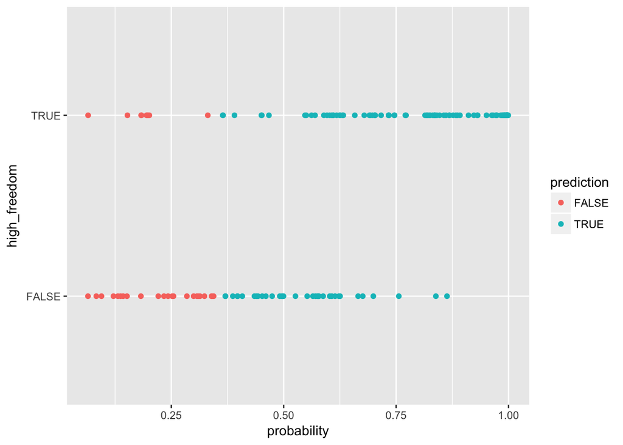

```r
g <- ggplot(happiness2_f, aes(x = probability, y = high_freedom, col = prediction))
g + geom_point()
```

```r
loss_func <- function(class, prob) {
  n_wrong <- abs(class - prob) > 0.35
  mean(n_wrong) }
loss_func(class = happiness2_f$highuse, prob = happiness2_f$probability)
```

```
## [1] NaN
```

Social support, corruption and generosity were statistically significant so they were used. Prediction does not capture right amount of high freedom or its magnitude. The predictive power of the model seems to be not very good. The plot shows insufficiency of the prediction. I don’t know why I got the not-a-number from the loss function (and ran out of time to learn that).

Next I did principal component analysis to see which variables are important in explaining variance. The variables are standardized before the analysis. Then I took rounded percentages of variance captured by principal components and created objects for axis labels before drawing a biplot.

```r
library(MASS); library(scales)
happiness2_std <- scale(happiness2)
pca_happiness2_std <- prcomp(happiness2_std)
pca_happiness2_std
```

```
## Standard deviations:
## [1] 1.9321708 1.1790957 0.8208650 0.7353431 0.5971637 0.4057012 0.3751035
##
## Rotation:
##                      PC1        PC2         PC3         PC4          PC5
## happ.score    -0.4815115  0.0778951 -0.02729338  0.04126956 -0.006702108
## gdpcapita     -0.4472240  0.2978299  0.04075715 -0.24405435 -0.089808304
## socialsupport -0.4152298  0.1657552 -0.22733945  0.44544964  0.671248217
## hlifeexp      -0.4325715  0.2557918 -0.11841919 -0.42524971 -0.340128055
## freedom       -0.3474510 -0.4072993  0.10635732  0.60465030 -0.549535239
## corruption    -0.2687311 -0.4740094  0.69401346 -0.30577957  0.339268987
## generosity    -0.1251594 -0.6494212 -0.66251116 -0.31680983  0.092389736
##                       PC6         PC7
## happ.score    -0.86013716  0.14053489
## gdpcapita      0.38025926  0.70526716
## socialsupport  0.23679637 -0.20821654
## hlifeexp       0.14599680 -0.64466260
## freedom        0.18508670 -0.01500645
## corruption     0.05169970 -0.10082957
## generosity     0.03534729  0.11624278
```

```r
s_std <- summary(pca_happiness2_std)
s_std
```

```
## Importance of components:
##                           PC1    PC2     PC3     PC4     PC5     PC6
## Standard deviation     1.9322 1.1791 0.82086 0.73534 0.59716 0.40570
## Proportion of Variance 0.5333 0.1986 0.09626 0.07725 0.05094 0.02351
## Cumulative Proportion  0.5333 0.7319 0.82820 0.90544 0.95639 0.97990
##                           PC7
## Standard deviation     0.3751
## Proportion of Variance 0.0201
## Cumulative Proportion  1.0000
```

```r
pca_pr_std <- round(100*s_std$importance[2,], digits = 1)
pca_pr_std
```

```
##  PC1  PC2  PC3  PC4  PC5  PC6  PC7
## 53.3 19.9  9.6  7.7  5.1  2.4  2.0
```

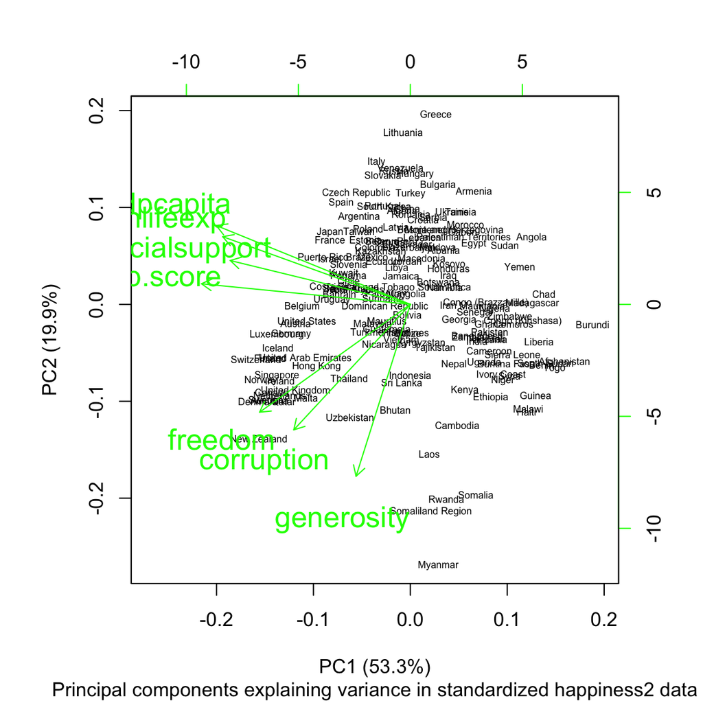

```r
pc_lab_std <- paste0(names(pca_pr_std), " (", pca_pr_std,"%)")
biplot(pca_happiness2_std, cex = c(0.5, 1.5), col = c("black", "green"), xlab = pc_lab_std[1], ylab = pc_lab_std[2], sub = "Principal components explaining variance in standardized happiness2 data")
```

The first principal component PC1 captures the maximum amount of variance from the features in the original data that is 53,3 %. This combination of variables capture most essential dimensions of the data. GDP per capita, healthy life expectancy, social support and happiness score contribute to PC1. This corresponds to results of the first regression model. The second principal component PC2 captures maximum amount of variability left. Freedom, corruption and generosity contribute to PC2. They explain 19,9 % of the variance.

It seems that GDP per capita, healthy life expectancy, social support and happiness score explain most of the variance from the features in the data. It means that they explain greater share of differences between countries. Freedom, corruption and generosity are not so constituent as them in making or explaining differences and trust-related variables not so essential in this sense.

Differences in GDP per capita and healthy life expectancy seem quite expected, between industrialised and developing countries. In the biplot we can see a high concentration of rich countries in the lower left corner. Not all x- and y-axis features are uncorrelated.

(I don’t know how to validate PCA analysis. Could it be done with train and test sets?)

#### Conclusions and discussion

GDP per capita, social support, healthy life expectancy, freedom and absence of corruption are positively correlated with happiness explaining 78 % of the variation of the happiness score. Some of the confidence intervals are wide, especially for healthy life expectancy and freedom. They are perhaps not the most powerful explainers for happiness.

Social support, absence of corruption and generosity are positively correlated with freedom, the correlations being not so strong though. Social support, corruption and generosity are positively correlated with high freedom (greater than 0,35). The variables get 20-28 times higher estimates than in the second model, but the odds ratios are large and confidence intervals wide. Maybe there is no point in this third regression and there should be other variables in addition. Anyway it seems that freedom has to do more with trust-related variables social support, corruption and generosity, although also contributing to the happiness score.

What comes to freedom, are social support, corruption and generosity forming some material prerequisites? I think social support can describe one’s situation, but it is not commensurate to assess society. Generosity is a weird measure in the sense that it can describe a society of low welfare based on charity or of high welfare with a strong third sector, but perhaps it would be useful to know research on it - maybe it is a telling variable. Absence of corruption is also just a perception. Together these all variables can be thought to somehow describe trust and abilities. There could be more questions for example on chances to educate oneself, move and speak out or out-of-pocket health care costs to improve measuring of freedom.